Load libraries.

```r
library(tidyr)
library(dplyr)
```

```r
library(pheatmap)
```

Set sample name variable.

Here for demonstration purposes, we will be looking at MP2B.

Then, read in the text file created by scCNV_to_clones_for_clonealign_wrapper.sh.

```r
sample="MP2B"

info <- read.table(paste0(sample,"_intersect_mappable_regions_one_copy_number_per_cell_region_combination.txt.gz"),header=FALSE,stringsAsFactors=FALSE)
```

Do some basic formatting including set column names, convert from long to wide (cell x region), remove non-autosomes.

```r
colnames(info) <- c("cell","region","copy_num")
info <- spread(info,key="region",value="copy_num")
rownames(info) <- info$cell
info <- info[,2:ncol(info)]
info <- info[,grep('chrX',colnames(info),invert=TRUE)]
info <- info[,grep('chrY',colnames(info),invert=TRUE)]
```

Also get the chr, start, and end info for each region in a separate table.

Region names are currently eg. “chr1:1-20000”, want to separate the chr1, 1, and 20000.

Also add a field for length (end - start), which we will use to weight regions for the mean per chromosome.

```r
chr_per_region <- sapply(strsplit(colnames(info),":"),"[[",1)
start_and_end_per_region <- sapply(strsplit(colnames(info),":"),"[[",2)
start_per_region <- as.numeric(sapply(strsplit(start_and_end_per_region,"-"),"[[",1))
end_per_region <- as.numeric(sapply(strsplit(start_and_end_per_region,"-"),"[[",2))
chr_per_region_numeric <- as.numeric(sapply(strsplit(chr_per_region,"chr"),"[[",2))
region_metadata <- data.frame(chr = chr_per_region_numeric,
    start = start_per_region,
    end = end_per_region,
    row.names=colnames(info),
    stringsAsFactors=FALSE)
region_metadata$length <- region_metadata$end - region_metadata$start
```

Get number of genes per region and add this to table.

```r
genes_per_region <- read.table(paste0(sample,"_mappable_regions_2Mb_num_intersecting_genes.txt"),
                               header=FALSE,stringsAsFactors=FALSE)
colnames(genes_per_region) <- c("region_name","num_genes")
region_metadata$region_name <- rownames(region_metadata)
old_regions <- region_metadata$region_name
region_metadata <- merge(region_metadata,genes_per_region,by="region_name")
setdiff(old_regions,region_metadata$region_name)
```

```
## [1] "chr1:122500000-124760000"
```

Looks like chr1:122500000-124760000 was removed because it has 0 genes matched to scRNA gene annotation. That’s fine.

Let’s proceed. Order regions by chr1,2,3, then start coordinate.

```r
info <- info[,region_metadata$region_name]
myorder <- order(region_metadata$chr,region_metadata$start)
region_metadata <- region_metadata[myorder,]
info <- info[,myorder]
```

Get the mean per chromosome by taking a weighted average based on the length of regions.

```r
mean_per_chr <- matrix(NA,nrow=nrow(info),ncol=22,dimnames=list(rownames(info),paste0("chr",1:22)))

for(chr in 1:22)
{
    chr_indices <- chr_indices <- which(region_metadata$chr == chr)
    info_this_chr <- info[,chr_indices]
    region_metadata_this_chr <- region_metadata[chr_indices,]
    region_metadata_this_chr$prop_chr <- region_metadata_this_chr$length/sum(region_metadata_this_chr$length)
    info_this_chr <- sweep(info_this_chr,2,region_metadata_this_chr$prop_chr,FUN="*")
    mean_per_chr[,chr] <- apply(info_this_chr,1,sum)
}
```

Get the median of these values across chromosomes, for each cell.

This is our custom “ploidy” value.

Then, remove cells with custom “ploidy” value more than one SD from the mean.

First include these cells on heatmap so we can see what they look like, then remove and replot heatmap.

```r
median_of_means_per_chr <- apply(mean_per_chr,1,median)

min_median_of_means_per_chr <- mean(median_of_means_per_chr) - sd(median_of_means_per_chr)
max_median_of_means_per_chr <- mean(median_of_means_per_chr) + sd(median_of_means_per_chr)

custom_ploidy_category_per_cell <- rep("In_range",times=nrow(info))
custom_ploidy_category_per_cell[median_of_means_per_chr < min_median_of_means_per_chr] <- "Low"
custom_ploidy_category_per_cell[median_of_means_per_chr > max_median_of_means_per_chr] <- "High"

custom_ploidy_category_per_cell_dat <- data.frame(ploidy = custom_ploidy_category_per_cell,
    row.names=rownames(info))
```

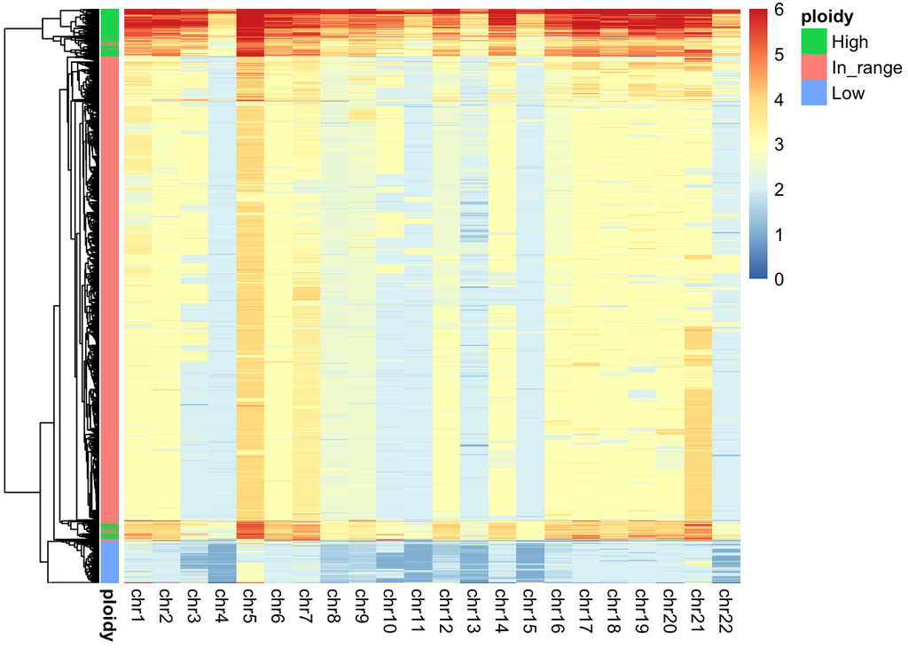

```r
mean_per_chr[mean_per_chr > 6] <- 6 #Truncate to show range in lower values better.

pheatmap(mean_per_chr,
    annotation_row=custom_ploidy_category_per_cell_dat,
    show_rownames=FALSE,
    cluster_cols=FALSE)
```

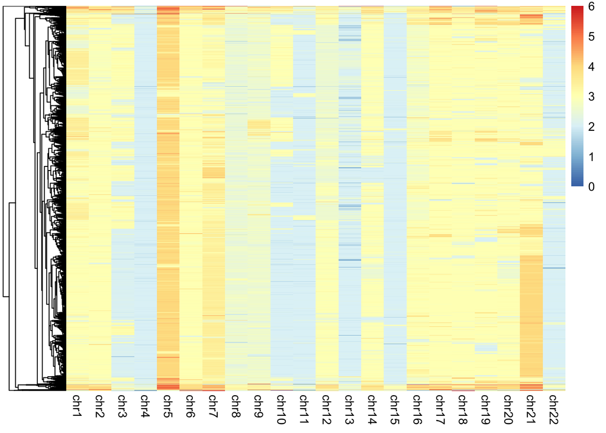

```r
info <- info[median_of_means_per_chr >= min_median_of_means_per_chr & median_of_means_per_chr <= max_median_of_means_per_chr,]
mean_per_chr <- mean_per_chr[rownames(info),]

pheatmap(mean_per_chr,
    show_rownames=FALSE,
    cluster_cols=FALSE)
```

The following chromosomes seem to warrant further review: 1,3,7,10,12,21

Let’s plot the actual regions for these.

```r
info_trunc <- info
info_trunc[info_trunc > 6] <- 6

region_indices <- which(region_metadata$chr %in% c(1,3,7,10,12,21))

region_metadata$chr_char <- paste0("chr",region_metadata$chr)

rownames(region_metadata) <- region_metadata$region_name
```

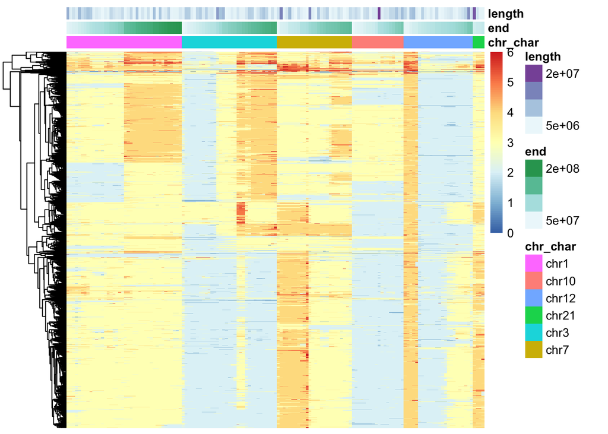

```r
pheatmap(info_trunc[,region_indices],
    show_rownames=FALSE,cluster_cols=FALSE,show_colnames=FALSE,
    annotation=region_metadata[,c("chr_char","end","length")])
```

Let’s look at each chromosome individually for some of these, so we can read the actual region coordinates.

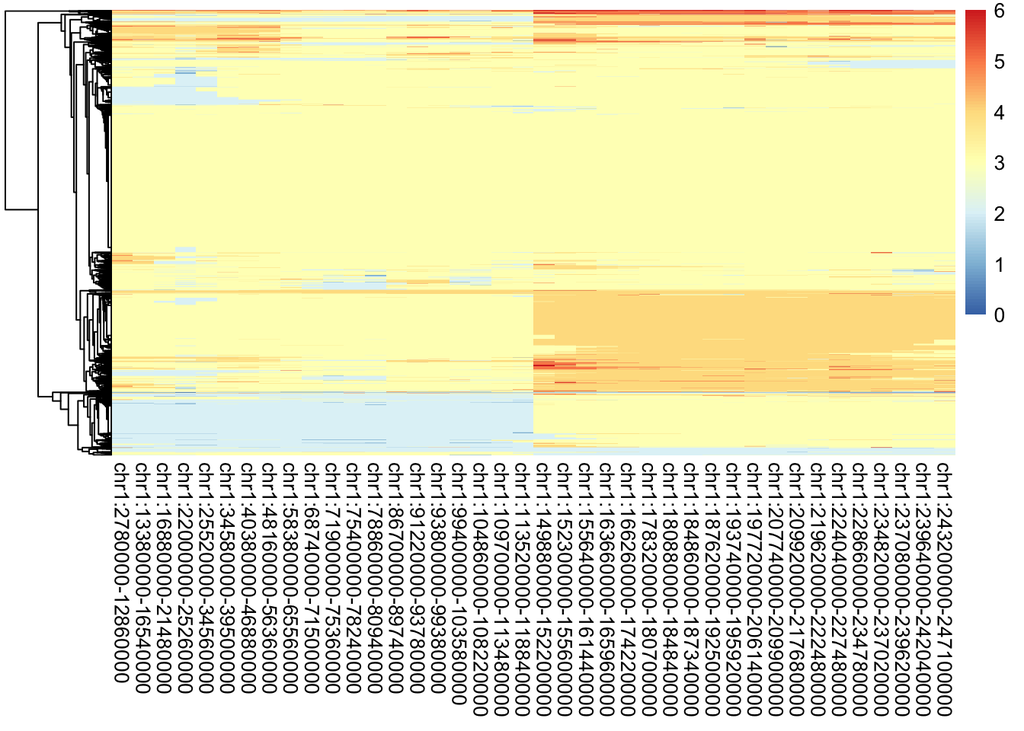

```r
pheatmap(info_trunc[,region_metadata$chr == 1],
    show_rownames=FALSE,cluster_cols=FALSE)
```

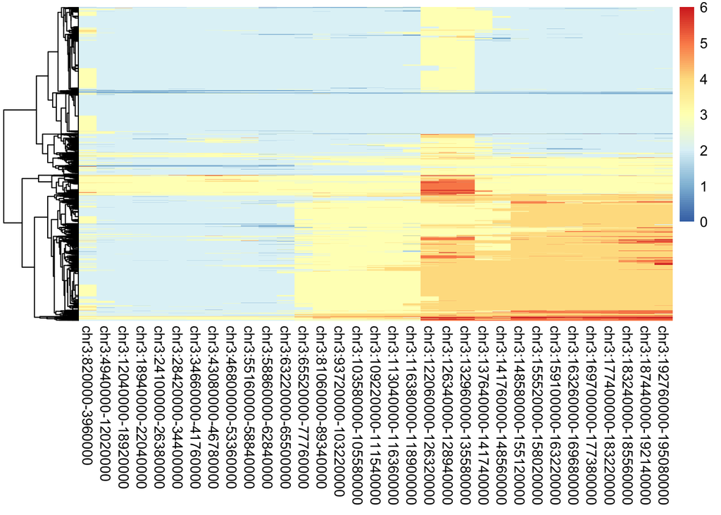

```r
pheatmap(info_trunc[,region_metadata$chr == 3],
    show_rownames=FALSE,cluster_cols=FALSE)
```

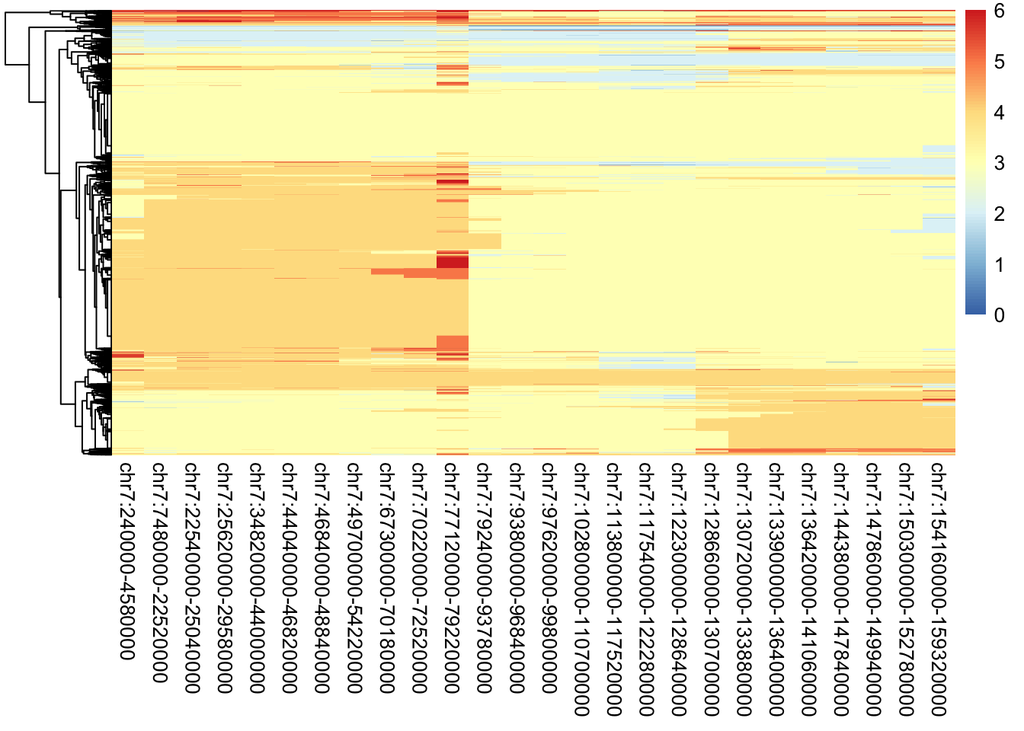

```r
pheatmap(info_trunc[,region_metadata$chr == 7],
    show_rownames=FALSE,cluster_cols=FALSE)
```

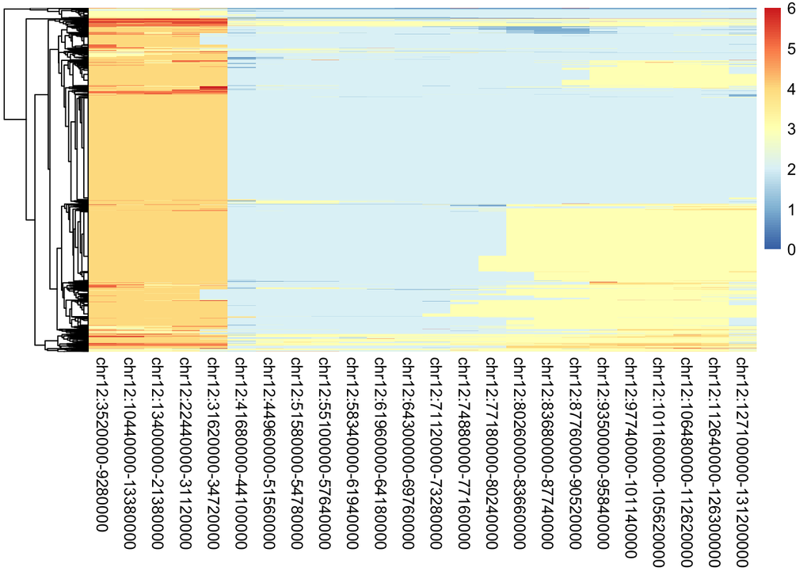

```r
pheatmap(info_trunc[,region_metadata$chr == 12],
    show_rownames=FALSE,cluster_cols=FALSE)
```

In chr1, looks like the region with copy number 3 vs. 4 starts at 149,880,000. This happens to also mean that we want to focus on the q arm.

In chr3, the earlier coordinates are mostly consistent between cells (copy number=2). Then, let’s focus only on the q arm (starts at >90Mb).

In chr7, later coordinates either are mostly the same between cells (copy number=3), or have lower frequency amplifications that are not consistent with the division into 2-3 clones we otherwise seem to be seeing. Let’s subset to just the p arm (ends at ~60Mb).

Finally in chr12, the p arm (up to ~35Mb) seems to be all the same (amplified) copy number. The start of the q arm also shows little variability (all copy number=2). So focus on only the end of the q arm.

```r
region_indices <- setdiff(region_indices,which(region_metadata$chr == 1 & region_metadata$start < 149e6))
region_indices <- setdiff(region_indices,which(region_metadata$chr == 3 & region_metadata$start < 90e6))
region_indices <- setdiff(region_indices,which(region_metadata$chr == 7 & region_metadata$start > 60e6))
region_indices <- setdiff(region_indices,which(region_metadata$chr == 12 & region_metadata$start < 80e6))
```

Remake heatmap.

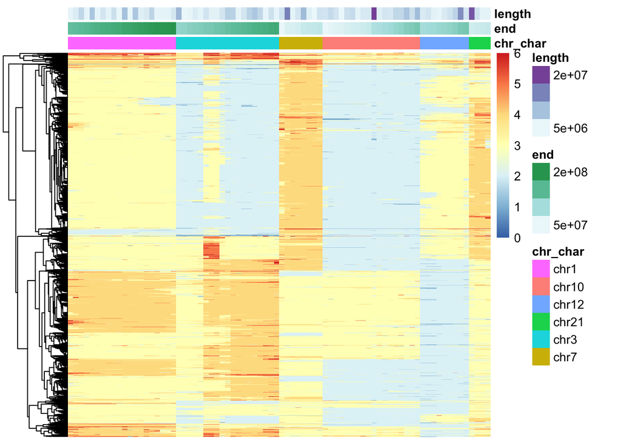

```r
pheatmap(info_trunc[,region_indices],
    show_rownames=FALSE,cluster_cols=FALSE,show_colnames=FALSE,
    annotation=region_metadata[,c("chr_char","end","length")])
```

Let’s also look at chr3 again.

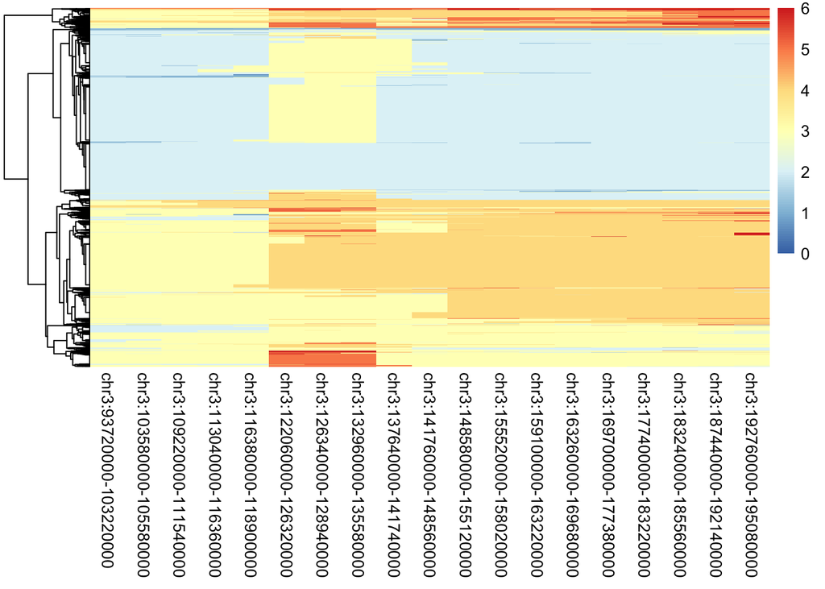

```r
pheatmap(info_trunc[,region_metadata$chr == 3 & 1:nrow(region_metadata) %in% region_indices],
    show_rownames=FALSE,cluster_cols=FALSE)
```

Looks like ~93.7-118.9Mb and ~148.58Mb onward show the most consistent pattern across adjacent segments. Let’s remove the regions in between.

```r
chr3_indices_to_remove <- which(region_metadata$chr == 3 & region_metadata$start >120e6 & region_metadata$start < 148e6)
region_indices <- setdiff(region_indices,chr3_indices_to_remove)
```

Also look at chr12 again.

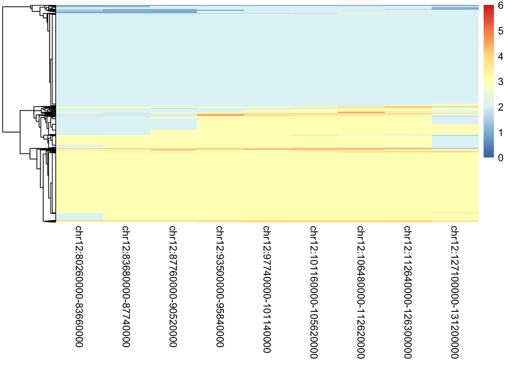

```r
pheatmap(info_trunc[,region_metadata$chr == 12 & 1:nrow(region_metadata) %in% region_indices],
         show_rownames=FALSE,cluster_cols=FALSE)
```

```r
chr12_indices_to_remove <- which(region_metadata$chr == 12 & (region_metadata$start <93e6 | region_metadata$start > 126e6))
region_indices <- setdiff(region_indices,chr12_indices_to_remove)
```

Let’s get the number of genes per chromosome after all this subsetting.

```r
region_metadata[region_indices,] %>% group_by(chr) %>% summarize(genes_per_chr = sum(num_genes))
```

```
## # A tibble: 6 x 2
##     chr genes_per_chr
##   <dbl>         <int>
## 1     1          1122
## 2     3           502
## 3     7           404
## 4    10           960
## 5    12           431
## 6    21           380
```

And redo the heatmap yet again.

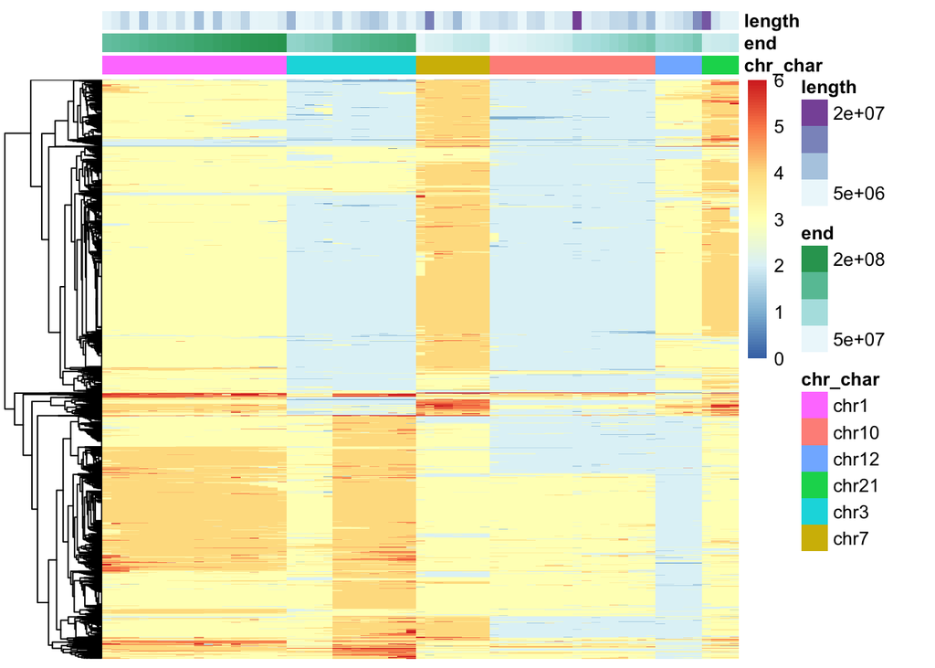

```r
pheatmap(info_trunc[,region_indices],
         show_rownames=FALSE,cluster_cols=FALSE,
         annotation=region_metadata[,c("chr_char","end","length")],
         show_colnames=FALSE)
```

What are the numbers of cells with each number of regions amplified (defined as the higher of the two main copy numbers present) for each chromosome?

```r
chr_of_interest <- c(1,3,7,10,12,21)
higher_copy_num <- c(4,3,4,3,3,4)

for(i in 1:length(chr_of_interest))
{
  indices_this_chr <- intersect(region_indices,which(region_metadata$chr == chr_of_interest[i]))
  regions_amp_per_cell <- apply(info[,indices_this_chr],1,FUN=function(x)sum(x >= higher_copy_num[i]))
  print(chr_of_interest[i])
  print(table(regions_amp_per_cell))
}
```

```
## [1] 1
## regions_amp_per_cell
##    0    1    2    3    4    5    6    7    8    9   10   11   12   13   14   15
## 1265   33   29   47   26   13   10    6    8    9    5    4    8   10    7   16
##   16   17   18   19   20
##   19   29   57   80  317
## [1] 3
## regions_amp_per_cell
##   0   1   2   3   4   5   6   7   8   9  10  11  12  13  14
## 843  50  30  15  11  10   5   4   7  57  16  18  28  46 858
## [1] 7
## regions_amp_per_cell
##   0   1   2   3   4   5   6   7   8
## 838  29   5  14  15  14  46 215 822
## [1] 10
## regions_amp_per_cell
##    0    1    2    3    4    5    6    7    8    9   10   11   12   13   14   15
## 1156  129   39   20   12    9    6    3    6   18    6    1    7    7   12   24
##   16   17   18
##   14   68  461
## [1] 12
## regions_amp_per_cell
##   0   1   2   3   4   5
## 917  16  15  18  38 994
## [1] 21
## regions_amp_per_cell
##   0   1   2   3   4
## 992  40  54 217 695
```

Let’s define the following number of regions to say that a chromosome/chromosome arm has high copy number.

chr1 - 16/20

chr3 - 12/14

chr7 - 6/8

chr10 - 14/18

chr12 - 4/5

chr21 - 3/4

Then, see what percent of cells have higher/lower copy number for each.

```r
amp_binary_matrix <- matrix(NA,nrow=nrow(info),ncol=6)
rownames(amp_binary_matrix) <- rownames(info)
colnames(amp_binary_matrix) <- paste0("chr",c(1,3,7,10,12,21))

chr_of_interest <- c(1,3,7,10,12,21)
higher_copy_num <- c(4,3,4,3,3,4)
num_regions_required <- c(16,12,6,14,4,3)

for(i in 1:length(chr_of_interest))
{
  indices_this_chr <- intersect(region_indices,which(region_metadata$chr == chr_of_interest[i]))
  regions_amp_per_cell <- apply(info[,indices_this_chr],1,FUN=function(x)sum(x >= higher_copy_num[i]))
  regions_amp_per_cell <- as.numeric(as.vector(regions_amp_per_cell))
  amp_binary_matrix[,i] <- ifelse(regions_amp_per_cell >= num_regions_required[i],1,0)
}

colSums(amp_binary_matrix)
```

```
##  chr1  chr3  chr7 chr10 chr12 chr21
##   502   932  1083   579  1032   912
```

It looks from the heatmap like one set of cells has the following set of chromosomes amplified: 1,3,10. Versus the other set of cells has the following: 7,12,21.

So, we should include at least one chromosome from each of these groups in our final clone definitions.

We also find that chr1 and chr10 have relatively fewer cells with amplification. So perhaps the clone with these cells amplified will be our secondary clone.

Let’s look at some confusion matrices for number of cells with amplification in one vs. both, for different pairs of chromosomes.

Also get a correlation coefficient.

```r
table(amp_binary_matrix[,"chr1"],
      amp_binary_matrix[,"chr3"])
```

```
##
##        0    1
##   0 1005  491
##   1   61  441
```

```r
cor(amp_binary_matrix[,"chr1"],amp_binary_matrix[,"chr3"])
```

```
## [1] 0.4784239
```

```r
table(amp_binary_matrix[,"chr1"],
      amp_binary_matrix[,"chr10"])
```

```
##
##        0    1
##   0 1284  212
##   1  135  367
```

```r
cor(amp_binary_matrix[,"chr1"],amp_binary_matrix[,"chr10"])
```

```
## [1] 0.5634704
```

```r
table(amp_binary_matrix[,"chr10"],
      amp_binary_matrix[,"chr3"])
```

```
##
##       0   1
##   0 997 422
##   1  69 510
```

```r
cor(amp_binary_matrix[,"chr3"],amp_binary_matrix[,"chr10"])
```

```
## [1] 0.5305637
```

```r
table(amp_binary_matrix[,"chr7"],
      amp_binary_matrix[,"chr12"])
```

```
##
##       0   1
##   0 796 119
##   1 170 913
```

```r
cor(amp_binary_matrix[,"chr7"],amp_binary_matrix[,"chr12"])
```

```
## [1] 0.710837
```

```r
table(amp_binary_matrix[,"chr7"],
      amp_binary_matrix[,"chr21"])
```

```
##
##       0   1
##   0 796 119
##   1 290 793
```

```r
cor(amp_binary_matrix[,"chr7"],amp_binary_matrix[,"chr21"])
```

```
## [1] 0.6023266
```

```r
table(amp_binary_matrix[,"chr12"],
      amp_binary_matrix[,"chr21"])
```

```
##
##       0   1
##   0 860 106
##   1 226 806
```

```r
cor(amp_binary_matrix[,"chr12"],amp_binary_matrix[,"chr21"])
```

```
## [1] 0.6734693
```

```r
table(amp_binary_matrix[,"chr1"],
      amp_binary_matrix[,"chr7"])
```

```
##
##        0    1
##   0  464 1032
##   1  451   51
```

```r
cor(amp_binary_matrix[,"chr1"],amp_binary_matrix[,"chr7"])
```

```
## [1] -0.5120965
```

```r
table(amp_binary_matrix[,"chr3"],
      amp_binary_matrix[,"chr7"])
```

```
##
##       0   1
##   0 181 885
##   1 734 198
```

```r
cor(amp_binary_matrix[,"chr3"],amp_binary_matrix[,"chr7"])
```

```
## [1] -0.6185596
```

```r
table(amp_binary_matrix[,"chr10"],
      amp_binary_matrix[,"chr7"])
```

```
##
##        0    1
##   0  394 1025
##   1  521   58
```

```r
cor(amp_binary_matrix[,"chr10"],amp_binary_matrix[,"chr7"])
```

```
## [1] -0.5665166
```

Some notes:

1. Looking at chromosomes with cells from the smaller clone amplified (1,3,10), we find many cells amplified in chr3 but not chr1/chr10.
2. If we want to use two chromosomes to define the larger clone (which we probably should since none of chr7,12,21 have a ton of genes on their own), chr 7 and 12 have the best correlation.
3. Chromosomes 1 and 10 have a lot more genes (1122 and 960 respectively) compared to chr3 (502). If we want to choose one of each of chr1/3/10 and chr7/12/21 as a first pass for defining clones, we should thus probably start with chr1 or chr10 over chr3.
4. Finally, chr10 has a very slightly better correlation rate with chr7 than chr1 does, so that more cells may be included in one of the two clones (1025+521=1546 compare to 1032+451=1483). So let’s start with using chr7 and chr10 to define clones.

Define clones, then remake heatmap with this info.

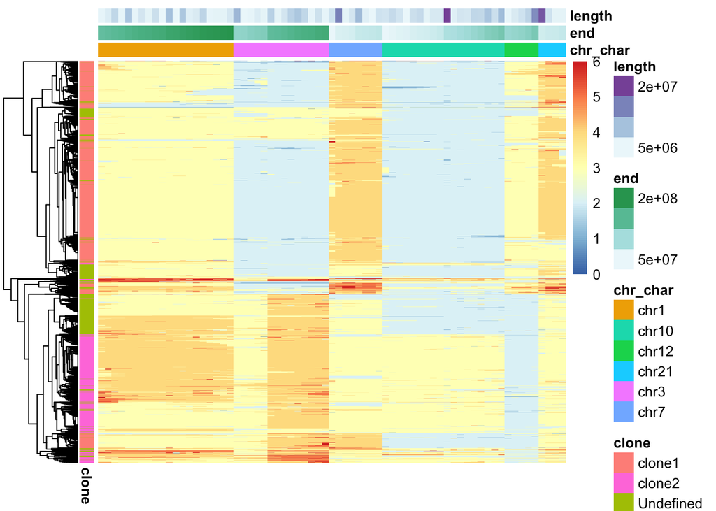

```r
clones <- rep("Undefined",times=nrow(info))
clones[amp_binary_matrix[,"chr7"] == 1 & amp_binary_matrix[,"chr10"] == 0] <- "clone1"
clones[amp_binary_matrix[,"chr7"] == 0 & amp_binary_matrix[,"chr10"] == 1] <- "clone2"

clones_dat <- data.frame(clone = clones,row.names=rownames(info))

pheatmap(info_trunc[,region_indices],
         show_rownames=FALSE,cluster_cols=FALSE,show_colnames=FALSE,
         annotation_row=clones_dat,
         annotation=region_metadata[,c("chr_char","end","length")])
```

And get the confusion matrix with remaining chromosomes.

```r
table(clones,amp_binary_matrix[,"chr1"])
```

```
##
## clones         0    1
##   clone1    1006   19
##   clone2     186  335
##   Undefined  304  148
```

```r
table(clones,amp_binary_matrix[,"chr3"])
```

```
##
## clones        0   1
##   clone1    862 163
##   clone2     46 475
##   Undefined 158 294
```

```r
table(clones,amp_binary_matrix[,"chr12"])
```

```
##
## clones        0   1
##   clone1    145 880
##   clone2    496  25
##   Undefined 325 127
```

```r
table(clones,amp_binary_matrix[,"chr21"])
```

```
##
## clones        0   1
##   clone1    266 759
##   clone2    482  39
##   Undefined 338 114
```

At first glance, none of these accuracy rates are that bad.

However, consider the lowest of the two rates if we separate clone1 and clone2.

chr1 - 335/(335 + 186)=64%

chr3 - 862/(862 + 163)=84%

chr12 - 880/(880 + 145)=86%

chr21 - 759/(759 + 266)=74%

A fairly large percent of clone2 cells (as we have defined them) do not have chr1 amplification.

While a large percent of clone1 cells do not have chr21 amplification.

In theory, it seems like we could have chr3 included as another chromosome amplified in clone2, though for whatever reason I did not for the publication. For this markdown, I will also print the coordinates for that chromosome, and will run clonealign including it. I expect to see that including chr3 increases the number of cells with sufficient expression for clonealign, but should change very few calls for the cells included in the paper (figures 2e-f).

Make another heatmap including only chr 7,10, and 12.

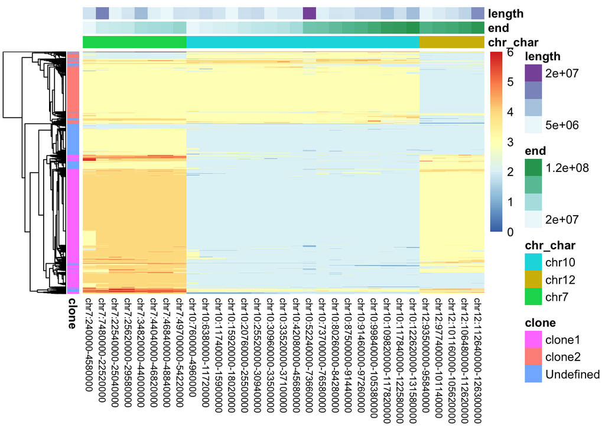

```r
region_indices_flt <- region_indices[region_metadata$chr[region_indices] %in% c(7,10,12)]

pheatmap(info_trunc[,region_indices_flt],
         show_rownames=FALSE,cluster_cols=FALSE,fontsize_col=8,
         annotation_row=clones_dat,
         annotation=region_metadata[,c("chr_char","end","length")])
```

Fewer cells have amplification for first region of chr7. Just remove that and then will have the set of coordinates used for clonealign.

```r
region_indices_flt <- region_indices_flt[2:length(region_indices_flt)]
```

Let’s print a version also with chr3 included, just to see how that looks in clonealign.

```r
region_indices_flt <- c(region_indices_flt,region_indices[region_metadata$chr[region_indices] == 3])

to_print <- region_metadata[region_indices_flt,]
to_print <- data.frame(chr = paste0("chr",to_print$chr),
                       to_print[,c("start","end")],
                       stringsAsFactors=FALSE)
clone1_copy_num <- rep(NA,times=nrow(to_print))
clone2_copy_num <- rep(NA,times=nrow(to_print))
clone1_copy_num[to_print$chr == "chr3"] <- 2
clone2_copy_num[to_print$chr == "chr3"] <- 3 #Really 2 vs. 4 for part of the chromosome in some cells, but others have only 3, so we have to set it to the lowest value since this is a two-clone model.
clone1_copy_num[to_print$chr == "chr10"] <- 2
clone2_copy_num[to_print$chr == "chr10"] <- 3
clone1_copy_num[to_print$chr == "chr7"] <- 4
clone2_copy_num[to_print$chr == "chr7"] <- 3
clone1_copy_num[to_print$chr == "chr12"] <- 3
clone2_copy_num[to_print$chr == "chr12"] <- 2

to_print$name <- paste0(clone1_copy_num,"_",clone2_copy_num)

write.table(to_print,file="MP2B_segment_by_clone_incl_chr3.bed",row.names=FALSE,col.names=FALSE,quote=FALSE,sep="\t")

to_print <- to_print[to_print$chr != "chr3",]

write.table(to_print,file="MP2B_segment_by_clone.bed",row.names=FALSE,col.names=FALSE,quote=FALSE,sep="\t")
```